## Project Title

### *‘Exploration of Factors that Effect Employee Productivity’*

```r
library(tidyverse)
library(dplyr)
library(car)
```

```r
library(ggplot2)
library(corrplot)
library(readr)
library(plotly)
library(rgl)
library(scales)
library(gridExtra)
library(vcd)
```

## Background

In a fast-paced corporate world where employee productivity determines the success and sustainability of organizations, This research project titled “Exploration of Factors that Contribute to Employee Productivity” aims to identify key drivers in that. Inspired by the ongoing discourse around work-life balance and its impact on performance, we aimed to untangle the complex web of variables influencing productivity in the workplace. Leveraging a comprehensive dataset from Kaggle, we investigated key factors, including monthly salary, work hours, remote work frequency, team size, and training opportunities. This project has not only provided actionable insights into optimizing resource allocation but also challenged traditional assumptions about performance drivers.

## Dataset Description

```r
library(readr)
productivity <- read.csv("Extended_Employee_Performance_and_Productivity_Data.csv")
summary(productivity)
```

```
##   Employee_ID      Department           Gender               Age
##  Min.   :     1   Length:100000      Length:100000      Min.   :22.00
##  1st Qu.: 25001   Class :character   Class :character   1st Qu.:31.00
##  Median : 50001   Mode  :character   Mode  :character   Median :41.00
##  Mean   : 50001                                         Mean   :41.03
##  3rd Qu.: 75000                                         3rd Qu.:51.00
##  Max.   :100000                                         Max.   :60.00
##   Job_Title          Hire_Date         Years_At_Company Education_Level
##  Length:100000      Length:100000      Min.   : 0.000   Length:100000
##  Class :character   Class :character   1st Qu.: 2.000   Class :character
##  Mode  :character   Mode  :character   Median : 4.000   Mode  :character
##                                        Mean   : 4.476
##                                        3rd Qu.: 7.000
##                                        Max.   :10.000
##  Performance_Score Monthly_Salary Work_Hours_Per_Week Projects_Handled
##  Min.   :1.000     Min.   :3850   Min.   :30.00       Min.   : 0.00
##  1st Qu.:2.000     1st Qu.:5250   1st Qu.:37.00       1st Qu.:12.00
##  Median :3.000     Median :6500   Median :45.00       Median :24.00
##  Mean   :2.995     Mean   :6403   Mean   :44.96       Mean   :24.43
##  3rd Qu.:4.000     3rd Qu.:7500   3rd Qu.:53.00       3rd Qu.:37.00
##  Max.   :5.000     Max.   :9000   Max.   :60.00       Max.   :49.00
##  Overtime_Hours    Sick_Days      Remote_Work_Frequency   Team_Size
##  Min.   : 0.00   Min.   : 0.000   Min.   :  0.00        Min.   : 1.00
##  1st Qu.: 7.00   1st Qu.: 3.000   1st Qu.: 25.00        1st Qu.: 5.00
##  Median :15.00   Median : 7.000   Median : 50.00        Median :10.00
##  Mean   :14.51   Mean   : 7.009   Mean   : 50.09        Mean   :10.01
##  3rd Qu.:22.00   3rd Qu.:11.000   3rd Qu.: 75.00        3rd Qu.:15.00
##  Max.   :29.00   Max.   :14.000   Max.   :100.00        Max.   :19.00
##  Training_Hours    Promotions     Employee_Satisfaction_Score
##  Min.   : 0.00   Min.   :0.0000   Min.   :1.000
##  1st Qu.:25.00   1st Qu.:0.0000   1st Qu.:2.010
##  Median :49.00   Median :1.0000   Median :3.000
##  Mean   :49.51   Mean   :0.9997   Mean   :2.999
##  3rd Qu.:75.00   3rd Qu.:2.0000   3rd Qu.:3.990
##  Max.   :99.00   Max.   :2.0000   Max.   :5.000
##    Resigned
##  Length:100000
##  Class :character
##  Mode  :character
##
##
##
```

```r
str(productivity)
```

```
## 'data.frame':    100000 obs. of  20 variables:
##  $ Employee_ID                : int  1 2 3 4 5 6 7 8 9 10 ...
##  $ Department                 : chr  "IT" "Finance" "Finance" "Customer Support" ...
##  $ Gender                     : chr  "Male" "Male" "Male" "Female" ...
##  $ Age                        : int  55 29 55 48 36 43 37 55 55 45 ...
##  $ Job_Title                  : chr  "Specialist" "Developer" "Specialist" "Analyst" ...
##  $ Hire_Date                  : chr  "2022-01-19 08:03:05.556036" "2024-04-18 08:03:05.556036" "2015-10-26 08:03:05.556036" "2016-10-22 08:03:05.556036" ...
##  $ Years_At_Company           : int  2 0 8 7 3 8 1 9 1 7 ...
##  $ Education_Level            : chr  "High School" "High School" "High School" "Bachelor" ...
##  $ Performance_Score          : int  5 5 3 2 2 3 5 2 2 1 ...
##  $ Monthly_Salary             : num  6750 7500 5850 4800 4800 7800 5250 7200 4200 6050 ...
##  $ Work_Hours_Per_Week        : int  33 34 37 52 38 46 55 42 51 41 ...
##  $ Projects_Handled           : int  32 34 27 10 11 31 20 46 23 33 ...
##  $ Overtime_Hours             : int  22 13 6 28 29 8 29 7 21 2 ...
##  $ Sick_Days                  : int  2 14 3 12 13 0 2 8 14 6 ...
##  $ Remote_Work_Frequency      : int  0 100 50 100 100 100 0 100 0 75 ...
##  $ Team_Size                  : int  14 12 10 10 15 15 16 7 1 4 ...
##  $ Training_Hours             : int  66 61 1 0 9 95 27 64 0 53 ...
##  $ Promotions                 : int  0 2 0 1 1 0 0 0 1 2 ...
##  $ Employee_Satisfaction_Score: num  2.63 1.72 3.17 1.86 1.25 2.77 4.46 2.09 1.44 2.93 ...
##  $ Resigned                   : chr  "False" "False" "False" "False" ...
```

**Source:**

The dataset can be accessed through Kaggle (Public library of useful datasets), titled *“Employee Performance and Producitvity Data.” (link :* https://www.kaggle.com/datasets/mexwell/employee-performance-and-productivity-data?)

- Rights: As the dataset is placed in public domain, there is no restrictions in sharing and usage.
- Limitations: The data seems a little bit unrealistic. In a lot of visualizations, it shows a very even split between Gender, Job Titles or Performance Scores

**Size:**

Number of Rows: 100000

Number of Columns: 20

**key Features:**

The dataset contains the following key attributes:

- Age: The current age of the employee, recorded in years
- Monthly_Salary: The total monthly salary of the employee, recorded in the organization’s currency.
- Years_At_Company: The number of years the employee has worked in the company.
- Remote_Work_Frequency : The frequency of remote work allowed or performed by the employee, often measured as a percentage or number of days.
- Work_Hours_Per_Week : The total hours worked per week by the employee, including overtime if applicable.
- Team_Size The team size the employee is part of, indicating their immediate working group.

Other Demographic Details: Additional information such as Sick_days, Promotion, and Overtime_hours.

## Analysis

### Part 1: Data Preparation

```r
#chaning the column types
productivity$Hire_Date <- as.Date(productivity$Hire_Date, format = "%Y-%m-%d") #removing the Hour Minute Second because it is not relevant for our analysis
productivity$Age <- as.numeric(productivity$Age)
productivity$Employee_ID <- as.numeric(productivity$Employee_ID)
productivity$Performance_Score <- as.numeric(productivity$Performance_Score)
productivity$Work_Hours_Per_Week <- as.numeric(productivity$Work_Hours_Per_Week)
productivity$Projects_Handled <- as.numeric(productivity$Projects_Handled)
productivity$Overtime_Hours <- as.numeric(productivity$Overtime_Hours)
productivity$Sick_Days <- as.numeric(productivity$Sick_Days)
productivity$Remote_Work_Frequency <- as.numeric(productivity$Remote_Work_Frequency)
productivity$Team_Size <- as.numeric(productivity$Team_Size)
productivity$Promotions <- as.numeric(productivity$Promotions)

str(productivity)
```

```
## 'data.frame':    100000 obs. of  20 variables:
##  $ Employee_ID                : num  1 2 3 4 5 6 7 8 9 10 ...
##  $ Department                 : chr  "IT" "Finance" "Finance" "Customer Support" ...
##  $ Gender                     : chr  "Male" "Male" "Male" "Female" ...
##  $ Age                        : num  55 29 55 48 36 43 37 55 55 45 ...
##  $ Job_Title                  : chr  "Specialist" "Developer" "Specialist" "Analyst" ...
##  $ Hire_Date                  : Date, format: "2022-01-19" "2024-04-18" ...
##  $ Years_At_Company           : int  2 0 8 7 3 8 1 9 1 7 ...
##  $ Education_Level            : chr  "High School" "High School" "High School" "Bachelor" ...
##  $ Performance_Score          : num  5 5 3 2 2 3 5 2 2 1 ...
##  $ Monthly_Salary             : num  6750 7500 5850 4800 4800 7800 5250 7200 4200 6050 ...
##  $ Work_Hours_Per_Week        : num  33 34 37 52 38 46 55 42 51 41 ...
##  $ Projects_Handled           : num  32 34 27 10 11 31 20 46 23 33 ...
##  $ Overtime_Hours             : num  22 13 6 28 29 8 29 7 21 2 ...
##  $ Sick_Days                  : num  2 14 3 12 13 0 2 8 14 6 ...
##  $ Remote_Work_Frequency      : num  0 100 50 100 100 100 0 100 0 75 ...
##  $ Team_Size                  : num  14 12 10 10 15 15 16 7 1 4 ...
##  $ Training_Hours             : int  66 61 1 0 9 95 27 64 0 53 ...
##  $ Promotions                 : num  0 2 0 1 1 0 0 0 1 2 ...
##  $ Employee_Satisfaction_Score: num  2.63 1.72 3.17 1.86 1.25 2.77 4.46 2.09 1.44 2.93 ...
##  $ Resigned                   : chr  "False" "False" "False" "False" ...
```

```r
#NAs
sum(is.na(productivity))
```

```
## [1] 0
```

```r
# zero NAs
```

```r
# Check for duplicate rows
duplicates <- productivity[duplicated(productivity), ] # View duplicate rows, if any
productivity <- productivity %>% distinct()

productivity
```

[output not shown]

[output cut: 24986 more lines]

```r
# Removing Outliers and Cleaning the Dataset

removing_outliers <- function(productivity, cols) {
  for (col in cols) {


    Q1 <- quantile(productivity[[col]], 0.25, na.rm = TRUE)
    Q3 <- quantile(productivity[[col]], 0.75, na.rm = TRUE)
    IQR <- Q3 - Q1


    lower_bound <- Q1 - 1.5 * IQR
    upper_bound <- Q3 + 1.5 * IQR


    productivity <- productivity %>%
      filter(.data[[col]] >= lower_bound & .data[[col]] <= upper_bound)
  }
  return(productivity)
}

cols <- c("Age", "Work_Hours_Per_Week", "Overtime_Hours", "Remote_Work_Frequency", "Sick_Days","Years_At_Company", "Monthly_Salary", "Projects_Handled", "Training_Hours", "Employee_Satisfaction_Score")


final_cleaned_dataset <- removing_outliers(productivity, cols)

str(final_cleaned_dataset)
```

```
## 'data.frame':    100000 obs. of  20 variables:
##  $ Employee_ID                : num  1 2 3 4 5 6 7 8 9 10 ...
##  $ Department                 : chr  "IT" "Finance" "Finance" "Customer Support" ...
##  $ Gender                     : chr  "Male" "Male" "Male" "Female" ...
##  $ Age                        : num  55 29 55 48 36 43 37 55 55 45 ...
##  $ Job_Title                  : chr  "Specialist" "Developer" "Specialist" "Analyst" ...
##  $ Hire_Date                  : Date, format: "2022-01-19" "2024-04-18" ...
##  $ Years_At_Company           : int  2 0 8 7 3 8 1 9 1 7 ...
##  $ Education_Level            : chr  "High School" "High School" "High School" "Bachelor" ...
##  $ Performance_Score          : num  5 5 3 2 2 3 5 2 2 1 ...
##  $ Monthly_Salary             : num  6750 7500 5850 4800 4800 7800 5250 7200 4200 6050 ...
##  $ Work_Hours_Per_Week        : num  33 34 37 52 38 46 55 42 51 41 ...
##  $ Projects_Handled           : num  32 34 27 10 11 31 20 46 23 33 ...
##  $ Overtime_Hours             : num  22 13 6 28 29 8 29 7 21 2 ...
##  $ Sick_Days                  : num  2 14 3 12 13 0 2 8 14 6 ...
##  $ Remote_Work_Frequency      : num  0 100 50 100 100 100 0 100 0 75 ...
##  $ Team_Size                  : num  14 12 10 10 15 15 16 7 1 4 ...
##  $ Training_Hours             : int  66 61 1 0 9 95 27 64 0 53 ...
##  $ Promotions                 : num  0 2 0 1 1 0 0 0 1 2 ...
##  $ Employee_Satisfaction_Score: num  2.63 1.72 3.17 1.86 1.25 2.77 4.46 2.09 1.44 2.93 ...
##  $ Resigned                   : chr  "False" "False" "False" "False" ...
```

Comment: The CSV file was downloaded and subsequently imported into R Studio for preprocessing. During this stage, the column types were adjusted to appropriate formats, such as numeric and date. The date column was refined from the original “Year-Month-Day Hour-Minute-Second” format to “Year-Month-Day,” as the time component (Hour-Minute-Second) was deemed irrelevant for the scope of this analysis. A thorough check for missing values (NAs) was conducted, confirming the absence of such entries.

### Part 2: Visualisation

```r
# getting an overview of the gender distribution
gender_counts <- table(final_cleaned_dataset$Gender)
print(gender_counts)
```

```
##
## Female   Male  Other
##  48001  48031   3968
```

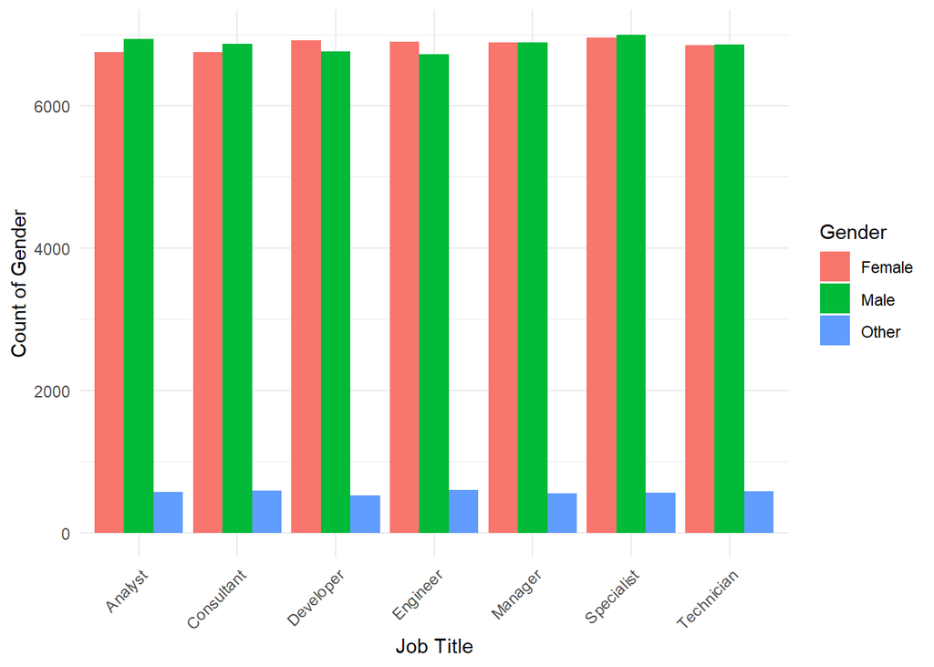

```r
# plotting
gender_count <- final_cleaned_dataset %>%
  group_by(Job_Title, Gender) %>%
  summarise(count = n(), .groups = 'drop')

ggplot(gender_count, aes(x = Job_Title, y = count, fill = Gender)) +
    geom_bar(stat = "identity", position = "dodge") +
    labs(
        x = "Job Title",
        y = "Count of Gender"
    ) +
    theme_minimal() +
    theme(axis.text.x = element_text(angle = 45, hjust = 1))
```

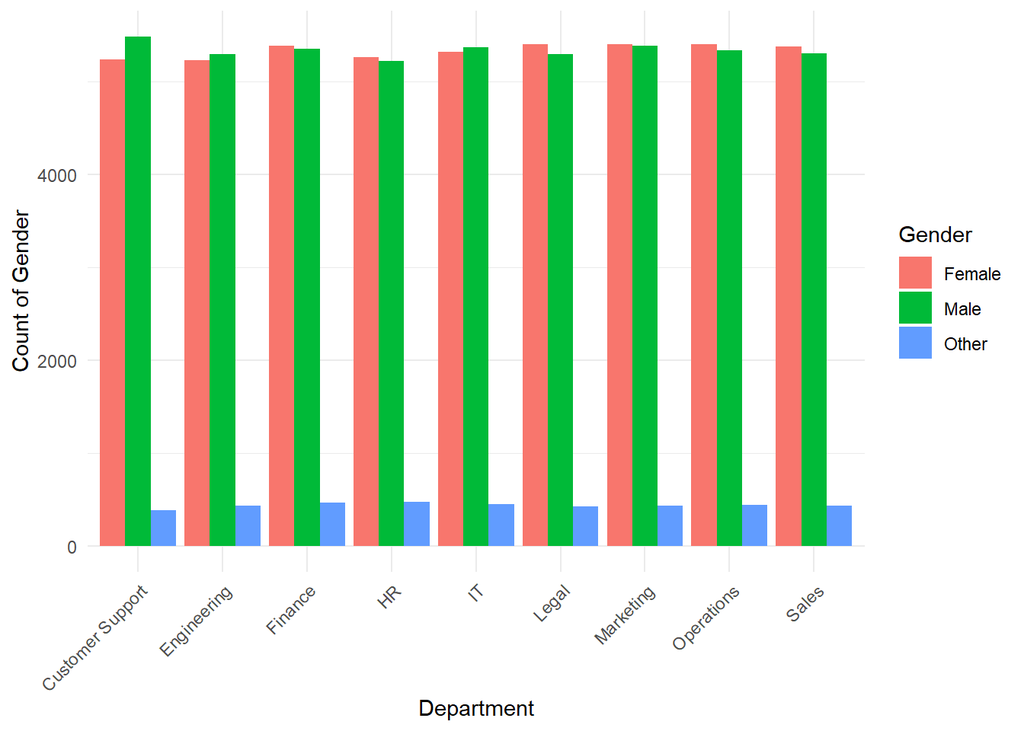

```r
# plotting
gender_count <- final_cleaned_dataset %>%
  group_by(Department, Gender) %>%
  summarise(count = n(), .groups = 'drop')

ggplot(gender_count, aes(x = Department, y = count, fill = Gender)) +
    geom_bar(stat = "identity", position = "dodge") +
    labs(
        x = "Department",
        y = "Count of Gender"
    ) +
    theme_minimal() +
    theme(axis.text.x = element_text(angle = 45, hjust = 1))
```

**Comment:** The distribution of gender appears balanced across job titles and departments, with roughly equal representation of males and females. This uniformity might indicate a conscious effort toward equal gender representation, although it also raises questions about dataset randomness or potential data constraints.

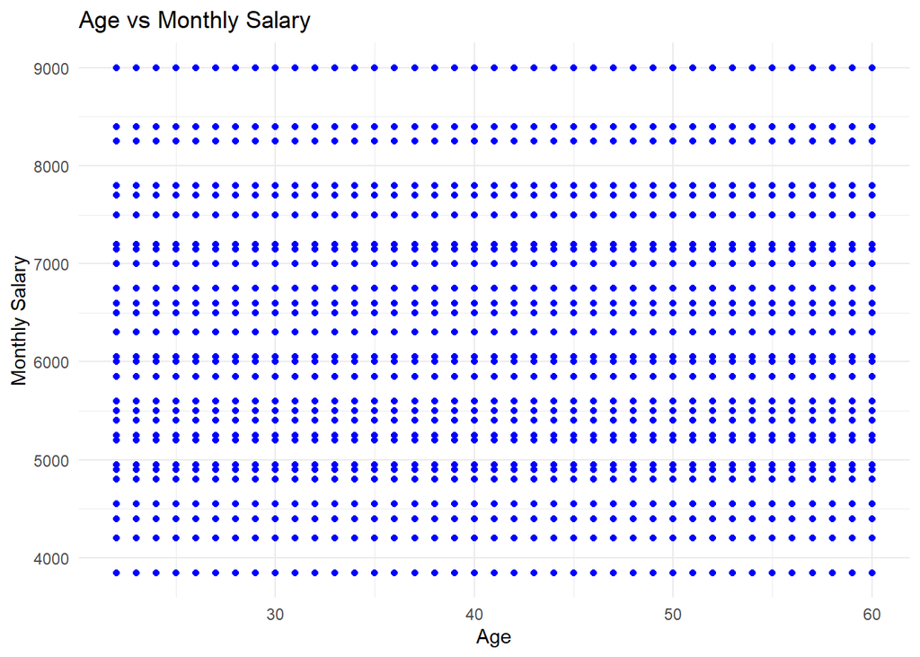

```r
#Plotting age and monthly salary

ggplot(final_cleaned_dataset, aes(x = Age, y = Monthly_Salary)) +
    geom_point(color = "blue", alpha = 0.6) +
    labs(
        title = "Age vs Monthly Salary",
        x = "Age",
        y = "Monthly Salary"
    ) +
    theme_minimal()
```

**Comment:** The scatterplot shows no apparent trend or correlation between age and monthly salary. Salaries are uniformly distributed across all age groups, suggesting that factors other than age (e.g., job role, education, or performance) are likely driving compensation.

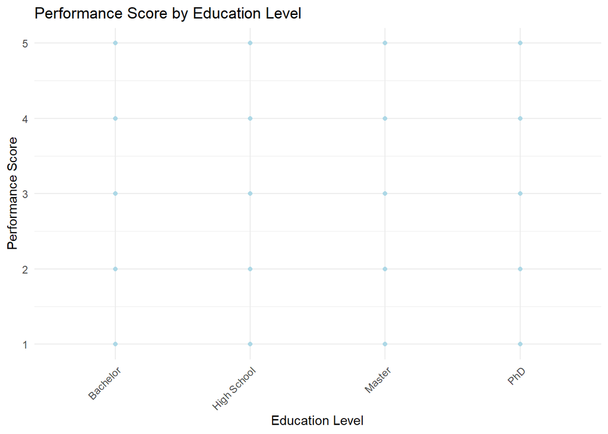

```r
#plotting performnce score over education level
ggplot(final_cleaned_dataset, aes(x = Education_Level, y = Performance_Score)) +
    geom_point(color = "lightblue", alpha = 0.6) +
    labs(
        title = "Performance Score by Education Level",
        x = "Education Level",
        y = "Performance Score"
    ) +
    theme_minimal() +
    theme(axis.text.x = element_text(angle = 45, hjust = 1))
```

**Comment:** Higher education levels (e.g., Master’s, Ph.D.) do not seem to guarantee higher performance scores, indicating that other factors (for example: training, work experience) may carry more weight in determining employee performance.

```r
#checking the count for every score
performance_counts <- table(final_cleaned_dataset$Performance_Score)
print(performance_counts)
```

```
##
##     1     2     3     4     5
## 20120 20013 19999 19940 19928
```

### Part 3 : Correlation Analysis

```r
corr_1 <- final_cleaned_dataset[, c("Performance_Score", "Employee_Satisfaction_Score")]
cor_matrix1 <- cor(corr_1, use = "complete.obs", method = "pearson")
print(cor_matrix1)
```

```
##                             Performance_Score Employee_Satisfaction_Score
## Performance_Score                 1.000000000                 0.001696279
## Employee_Satisfaction_Score       0.001696279                 1.000000000
```

```r
cor_2 <- final_cleaned_dataset[, c("Performance_Score", "Promotions")]
cor_matrix2 <- cor(cor_2)
print(cor_matrix2)
```

```
##                   Performance_Score   Promotions
## Performance_Score       1.000000000 -0.003501298
## Promotions             -0.003501298  1.000000000
```

```r
cor_3 <- final_cleaned_dataset[, c("Performance_Score", "Monthly_Salary")]
cor_matrix3 <- cor(cor_3)
print(cor_matrix3)
```

```
##                   Performance_Score Monthly_Salary
## Performance_Score         1.0000000      0.5100348
## Monthly_Salary            0.5100348      1.0000000
```

```r
cor_4 <- final_cleaned_dataset[, c("Performance_Score", "Age")]
cor_matrix4 <- cor(cor_4)
print(cor_matrix4)
```

```
##                   Performance_Score         Age
## Performance_Score       1.000000000 0.001597668
## Age                     0.001597668 1.000000000
```

```r
cor_5 <- final_cleaned_dataset[, c("Performance_Score", "Work_Hours_Per_Week")]
cor_matrix5 <- cor(cor_5)
print(cor_matrix5)
```

```
##                     Performance_Score Work_Hours_Per_Week
## Performance_Score         1.000000000        -0.005627252
## Work_Hours_Per_Week      -0.005627252         1.000000000
```

```r
cor_6 <- final_cleaned_dataset[, c("Performance_Score", "Overtime_Hours")]
cor_matrix6 <- cor(cor_6)
print(cor_matrix6)
```

```
##                   Performance_Score Overtime_Hours
## Performance_Score       1.000000000   -0.001311629
## Overtime_Hours         -0.001311629    1.000000000
```

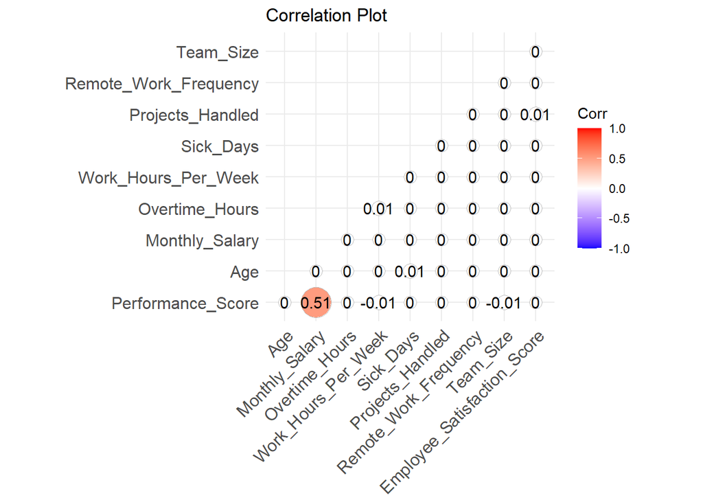

```r
library(ggcorrplot)
selected_columns <- final_cleaned_dataset[, c("Performance_Score", "Age", "Monthly_Salary", "Overtime_Hours", "Work_Hours_Per_Week", "Sick_Days", "Projects_Handled", "Remote_Work_Frequency", "Team_Size", "Employee_Satisfaction_Score")]

cor_matrix <- cor(selected_columns, use = "complete.obs")

ggcorrplot(cor_matrix,
           method = "circle",
           type = "lower",
           lab = TRUE,
           title = "Correlation Plot")
```

**Comment:** Correlation matrices were used to analyze relationships between variables, represented by Pearson correlation coefficients (ranging from -1 to 1). Most variables were independent, except for a notable positive correlation between Performance Score and Monthly Salary, indicating that higher performance scores are generally associated with increased salaries. This highlights the significant link between performance and compensation.

### Part 4 : Linear Regression

```r
#Regression Model Building
Model_employee <- lm(Performance_Score ~ Age + Gender + Resigned + Years_At_Company + Team_Size + Monthly_Salary + Work_Hours_Per_Week + Training_Hours + Projects_Handled+ Sick_Days+ + Promotions+ Overtime_Hours + Employee_Satisfaction_Score+  Remote_Work_Frequency + Education_Level ,data = final_cleaned_dataset)

summary(Model_employee)
```

```
##
## Call:
## lm(formula = Performance_Score ~ Age + Gender + Resigned + Years_At_Company +
##     Team_Size + Monthly_Salary + Work_Hours_Per_Week + Training_Hours +
##     Projects_Handled + Sick_Days + +Promotions + Overtime_Hours +
##     Employee_Satisfaction_Score + Remote_Work_Frequency + Education_Level,
##     data = final_cleaned_dataset)
##
## Residuals:
##      Min       1Q   Median       3Q      Max
## -2.15950 -0.93000 -0.04578  0.96658  2.65813
##
## Coefficients:
##                               Estimate Std. Error t value Pr(>|t|)
## (Intercept)                 -3.577e-01  3.667e-02  -9.754   <2e-16 ***
## Age                          2.083e-05  3.423e-04   0.061   0.9515
## GenderMale                   1.166e-02  7.854e-03   1.484   0.1377
## GenderOther                  7.301e-03  2.010e-02   0.363   0.7164
## ResignedTrue                -9.198e-03  1.282e-02  -0.717   0.4732
## Years_At_Company             9.657e-04  1.341e-03   0.720   0.4715
## Team_Size                   -1.715e-03  7.003e-04  -2.448   0.0143 *
## Monthly_Salary               5.257e-04  2.804e-06 187.502   <2e-16 ***
## Work_Hours_Per_Week         -7.015e-04  4.304e-04  -1.630   0.1031
## Training_Hours               1.450e-04  1.332e-04   1.089   0.2764
## Projects_Handled             1.559e-04  2.660e-04   0.586   0.5578
## Sick_Days                    3.749e-04  8.884e-04   0.422   0.6730
## Promotions                  -4.325e-03  4.717e-03  -0.917   0.3591
## Overtime_Hours               4.047e-05  4.442e-04   0.091   0.9274
## Employee_Satisfaction_Score  1.443e-03  3.344e-03   0.431   0.6661
## Remote_Work_Frequency        7.864e-05  1.089e-04   0.722   0.4701
## Education_LevelHigh School   1.382e-02  8.885e-03   1.555   0.1200
## Education_LevelMaster        2.377e-02  1.136e-02   2.093   0.0364 *
## Education_LevelPhD          -8.738e-03  1.797e-02  -0.486   0.6267
## ---
## Signif. codes:  0 '***' 0.001 '**' 0.01 '*' 0.05 '.' 0.1 ' ' 1
##
## Residual standard error: 1.217 on 99981 degrees of freedom
## Multiple R-squared:  0.2603, Adjusted R-squared:  0.2602
## F-statistic:  1955 on 18 and 99981 DF,  p-value: < 2.2e-16
```

**Comment:** A multiple regression analysis was conducted using Performance Score as the response variable and relevant predictors to identify factors influencing productivity. The results showed that only Monthly Salary, Team Size, and Master’s Degree (education level) were statistically significant, with p-values below 0.05. Higher salaries were strongly linked to better performance, making Monthly Salary the most influential factor. Employees with a Master’s degree also tended to perform better, while larger team sizes negatively impacted individual performance. However, the low R-squared value suggests these factors explain only a small portion of the variability in performance, indicating the need for further exploration of additional variables.

```r
#Refining the model for better fit based on results

refined_model_employee <- lm(Performance_Score ~ Monthly_Salary +Education_Level+  Team_Size, data = final_cleaned_dataset)
summary(refined_model_employee)
```

```
##
## Call:
## lm(formula = Performance_Score ~ Monthly_Salary + Education_Level +
##     Team_Size, data = final_cleaned_dataset)
##
## Residuals:
##      Min       1Q   Median       3Q      Max
## -2.13087 -0.93335 -0.04605  0.97063  2.64237
##
## Coefficients:
##                              Estimate Std. Error t value Pr(>|t|)
## (Intercept)                -3.610e-01  2.000e-02 -18.048   <2e-16 ***
## Monthly_Salary              5.257e-04  2.804e-06 187.514   <2e-16 ***
## Education_LevelHigh School  1.381e-02  8.885e-03   1.554   0.1201
## Education_LevelMaster       2.375e-02  1.136e-02   2.091   0.0365 *
## Education_LevelPhD         -8.861e-03  1.797e-02  -0.493   0.6218
## Team_Size                  -1.716e-03  7.002e-04  -2.451   0.0143 *
## ---
## Signif. codes:  0 '***' 0.001 '**' 0.01 '*' 0.05 '.' 0.1 ' ' 1
##
## Residual standard error: 1.217 on 99994 degrees of freedom
## Multiple R-squared:  0.2602, Adjusted R-squared:  0.2602
## F-statistic:  7035 on 5 and 99994 DF,  p-value: < 2.2e-16
```

```r
#Need to extract number values from the model

coeff_table_2 <- refined_model_employee$coefficients
rounded_coefficients_2 <- round(coeff_table_2, 2)
rounded_coefficients_2
```

```
##                (Intercept)             Monthly_Salary
##                      -0.36                       0.00
## Education_LevelHigh School      Education_LevelMaster
##                       0.01                       0.02
##         Education_LevelPhD                  Team_Size
##                      -0.01                       0.00
```

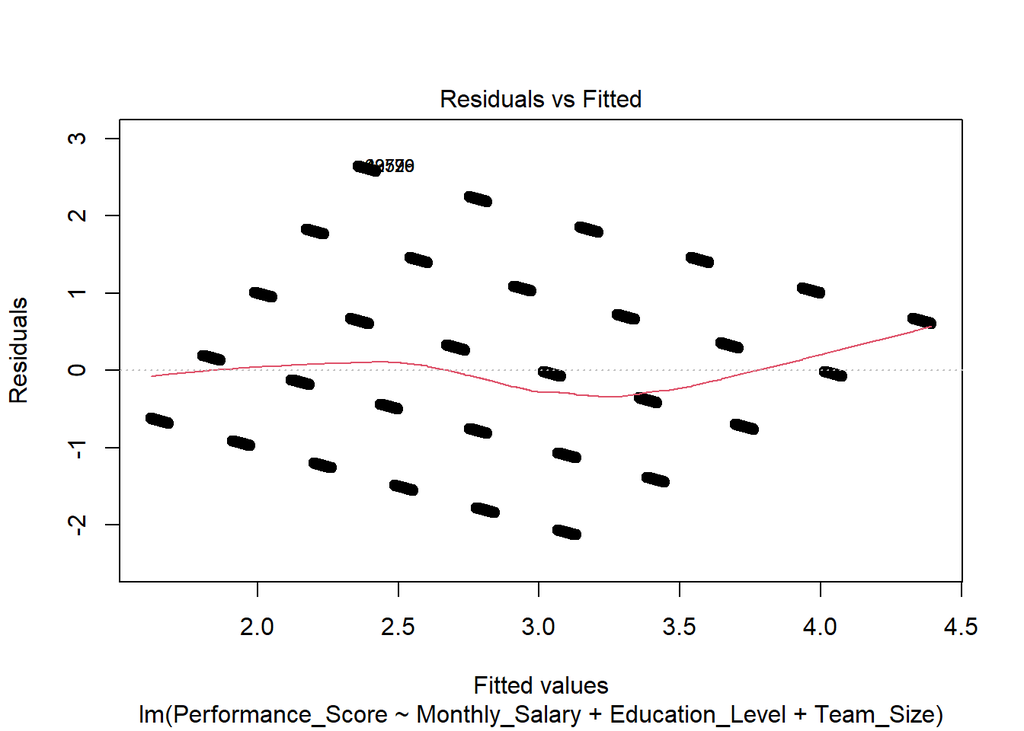

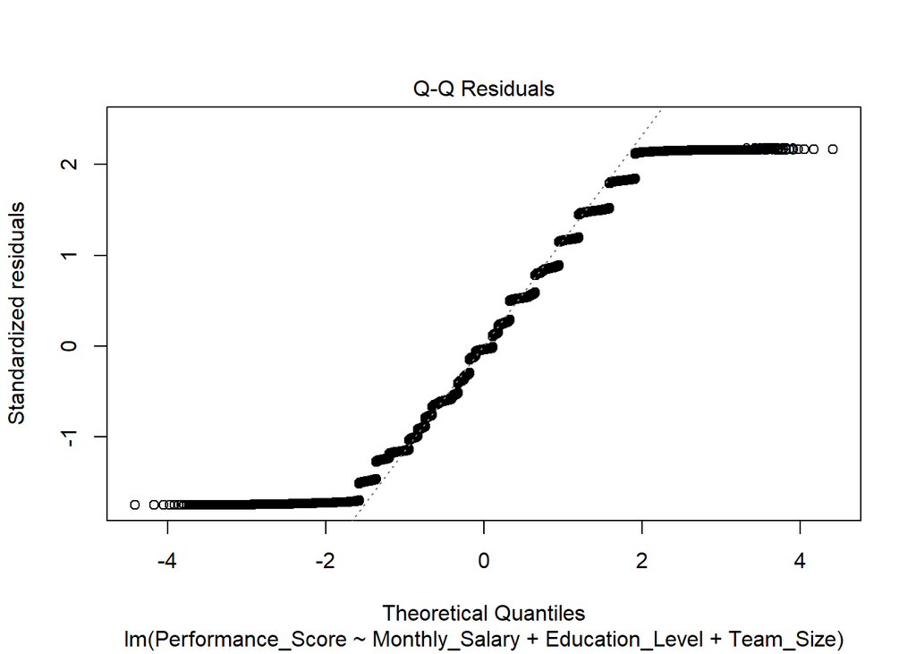

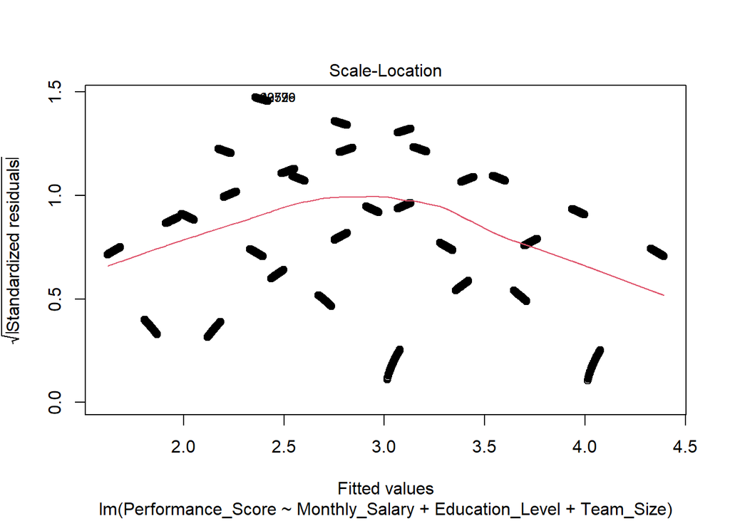

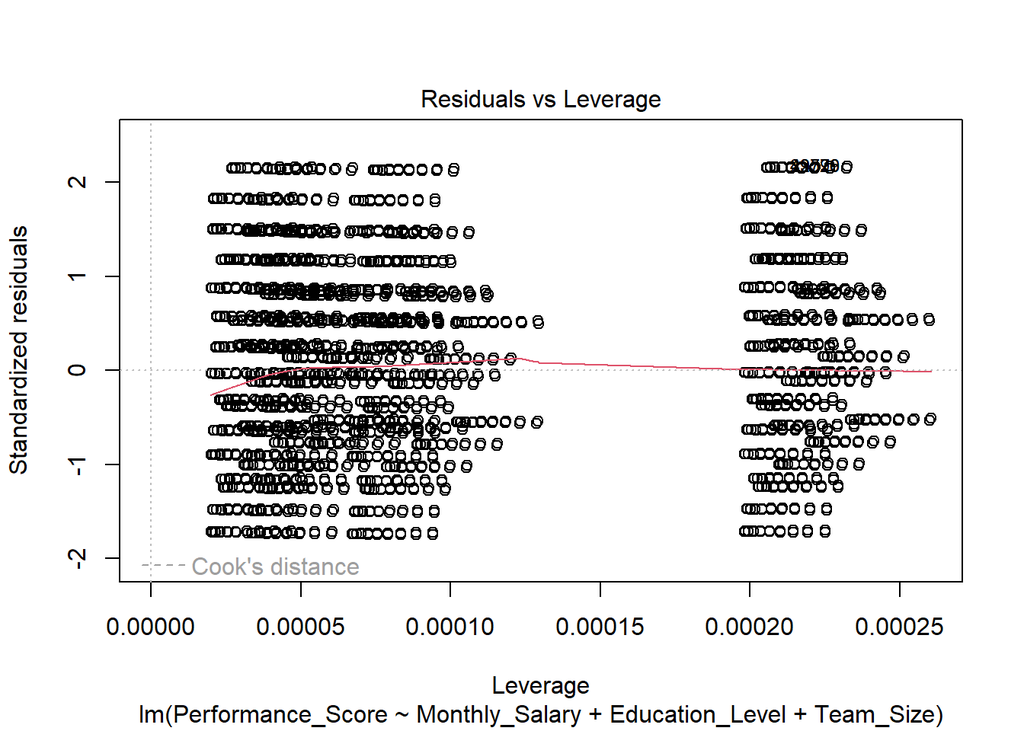

```r
plot(refined_model_employee)
```

```r
vif(refined_model_employee)
```

```
##                     GVIF Df GVIF^(1/(2*Df))
## Monthly_Salary  1.000055  1        1.000027
## Education_Level 1.000069  3        1.000011
## Team_Size       1.000032  1        1.000016
```

```r
#Exploring interaction model

interaction_model_employee <- lm(Performance_Score ~ Monthly_Salary * Education_Level + Team_Size , data = final_cleaned_dataset)

summary(interaction_model_employee)
```

```
##
## Call:
## lm(formula = Performance_Score ~ Monthly_Salary * Education_Level +
##     Team_Size, data = final_cleaned_dataset)
##
## Residuals:
##      Min       1Q   Median       3Q      Max
## -2.13016 -0.93167 -0.04596  0.96945  2.65364
##
## Coefficients:
##                                             Estimate Std. Error t value
## (Intercept)                               -3.609e-01  2.687e-02 -13.430
## Monthly_Salary                             5.257e-04  3.967e-06 132.525
## Education_LevelHigh School                 1.155e-02  4.233e-02   0.273
## Education_LevelMaster                      4.818e-02  5.426e-02   0.888
## Education_LevelPhD                        -7.037e-02  8.638e-02  -0.815
## Team_Size                                 -1.715e-03  7.002e-04  -2.449
## Monthly_Salary:Education_LevelHigh School  3.536e-07  6.468e-06   0.055
## Monthly_Salary:Education_LevelMaster      -3.806e-06  8.273e-06  -0.460
## Monthly_Salary:Education_LevelPhD          9.564e-06  1.314e-05   0.728
##                                           Pr(>|t|)
## (Intercept)                                 <2e-16 ***
## Monthly_Salary                              <2e-16 ***
## Education_LevelHigh School                  0.7850
## Education_LevelMaster                       0.3746
## Education_LevelPhD                          0.4153
## Team_Size                                   0.0143 *
## Monthly_Salary:Education_LevelHigh School   0.9564
## Monthly_Salary:Education_LevelMaster        0.6455
## Monthly_Salary:Education_LevelPhD           0.4668
## ---
## Signif. codes:  0 '***' 0.001 '**' 0.01 '*' 0.05 '.' 0.1 ' ' 1
##
## Residual standard error: 1.217 on 99991 degrees of freedom
## Multiple R-squared:  0.2602, Adjusted R-squared:  0.2602
## F-statistic:  4397 on 8 and 99991 DF,  p-value: < 2.2e-16
```

**Comment:** An interaction model was developed to examine whether the combination of high salary and high education level has a significant effect on performance. However, the analysis revealed no improvement in the model’s R-squared value, indicating that the interaction terms did not enhance the model’s explanatory power.

```r
#Exploring taking log of response variable
final_cleaned_dataset$log_performance <- log(final_cleaned_dataset$Performance_Score)
#refined_log_model
log_model <- lm(log_performance ~ Monthly_Salary +Team_Size +Education_Level , data = final_cleaned_dataset)
summary(log_model)
```

```
##
## Call:
## lm(formula = log_performance ~ Monthly_Salary + Team_Size + Education_Level,
##     data = final_cleaned_dataset)
##
## Residuals:
##      Min       1Q   Median       3Q      Max
## -1.00917 -0.42019  0.06686  0.38651  0.90584
##
## Coefficients:
##                              Estimate Std. Error t value Pr(>|t|)
## (Intercept)                -3.575e-01  8.122e-03 -44.016   <2e-16 ***
## Monthly_Salary              2.056e-04  1.139e-06 180.560   <2e-16 ***
## Team_Size                  -5.790e-04  2.843e-04  -2.036   0.0417 *
## Education_LevelHigh School  4.585e-03  3.608e-03   1.271   0.2038
## Education_LevelMaster       1.049e-02  4.611e-03   2.275   0.0229 *
## Education_LevelPhD         -7.142e-03  7.295e-03  -0.979   0.3276
## ---
## Signif. codes:  0 '***' 0.001 '**' 0.01 '*' 0.05 '.' 0.1 ' ' 1
##
## Residual standard error: 0.4941 on 99994 degrees of freedom
## Multiple R-squared:  0.2459, Adjusted R-squared:  0.2459
## F-statistic:  6523 on 5 and 99994 DF,  p-value: < 2.2e-16
```

```r
# Exploring taking log of both sides
final_cleaned_dataset$log_monthly_salary <- log(final_cleaned_dataset$Monthly_Salary)

#refined_log_model_2
log_model_2 <- lm(log_performance ~ log_monthly_salary + Education_Level + Team_Size  , data = final_cleaned_dataset)
summary(log_model_2)
```

```
##
## Call:
## lm(formula = log_performance ~ log_monthly_salary + Education_Level +
##     Team_Size, data = final_cleaned_dataset)
##
## Residuals:
##      Min       1Q   Median       3Q      Max
## -1.03701 -0.34100  0.07149  0.37174  0.88951
##
## Coefficients:
##                              Estimate Std. Error  t value Pr(>|t|)
## (Intercept)                -1.007e+01  6.221e-02 -161.894   <2e-16 ***
## log_monthly_salary          1.262e+00  7.107e-03  177.566   <2e-16 ***
## Education_LevelHigh School  4.784e-03  3.623e-03    1.321   0.1866
## Education_LevelMaster       1.055e-02  4.630e-03    2.278   0.0227 *
## Education_LevelPhD         -7.222e-03  7.325e-03   -0.986   0.3241
## Team_Size                  -5.845e-04  2.855e-04   -2.047   0.0406 *
## ---
## Signif. codes:  0 '***' 0.001 '**' 0.01 '*' 0.05 '.' 0.1 ' ' 1
##
## Residual standard error: 0.4961 on 99994 degrees of freedom
## Multiple R-squared:  0.2398, Adjusted R-squared:  0.2398
## F-statistic:  6308 on 5 and 99994 DF,  p-value: < 2.2e-16
```

**Comment:** The model was further refined by applying a logarithmic transformation to both Performance Score and Monthly Salary, the most statistically significant factor. Despite this adjustment, the R-squared value remained low, indicating no improvement in the model’s explanatory power.

## Results / Insights

This analysis concludes that the most reliable regression model for this dataset identifies Monthly Salary, Team Size, and Education Level as the strongest predictors of employee performance, with Monthly Salary being the most significant. Despite attempts to refine the model through transformations and interaction terms, no improvements in explanatory power were observed, reinforcing this model as the best representation of the data. These findings highlight the critical influence of compensation, team dynamics, and education on employee productivity. The analysis also underscores the importance of addressing underlying data complexities and exploring additional factors to enhance the predictive strength of the models.